# Differential Expression-like analysis

Nastassia Gobet, Maxime Jan

3 September 2019 -

# GOAL

Perform differential expression-like analysis, expect that to compare STAR (alignment) vs Kallisto (pseudo-alignment) mapping on B6 mm10 primary assembly (refered after as B6). Differential mapping analysis.

# DATA

## gene expression table

The input data are raw counts of gene expression (counted per sample by ht-count, then grouped). Rows are genes and columns are libraries/samples. (One library per sample, no replicate except for parental lines). Samples are mouse lines + condition (SD or NSD).

### Loading

```r
# load STAR counts
countsCortexSTAR <- read.table("F:/BXD/data/transcriptome/3_counting_htseq/B6mm10/count_B6mm10_cortex.txt", header=TRUE, row.names=1, stringsAsFactors=FALSE)
countsLiverSTAR <- read.table("F:/BXD/data/transcriptome/3_counting_htseq/B6mm10/count_B6mm10_liver.txt", header=TRUE, row.names=1, stringsAsFactors=FALSE)

# load B6 mm10 geneID to gene name convert table
B6mm10geneConvert <- read.table("F:/BXD/references/gene_names_B6mm10.tab", header=FALSE, stringsAsFactors=FALSE, sep=" ")
colnames(B6mm10geneConvert) <- c("GeneID", "GeneName")
# remove B6 replicate gene names
B6mm10geneConvert <- B6mm10geneConvert[-which(duplicated(B6mm10geneConvert$GeneName)),]
rownames(B6mm10geneConvert) <- 1:nrow(B6mm10geneConvert)
### could be improved by adding the counts from different transcripts

# try to find B6 matching names
idx <- na.omit(match(rownames(countsCortexSTAR),B6mm10geneConvert$GeneID))
# take B6 subset
countsCortexSTAR <- countsCortexSTAR[B6mm10geneConvert$GeneID[idx],]
countsLiverSTAR <- countsLiverSTAR[B6mm10geneConvert$GeneID[idx],]
# convert B6 rownames (GeneID) into gene name
rownames(countsCortexSTAR) <- B6mm10geneConvert$GeneName[idx]
rownames(countsLiverSTAR) <- B6mm10geneConvert$GeneName[idx]
```

```r
# load Kallisto counts
RNA <- read.table("F:/BXD/data/transcriptome/2.5_quantification_Kallisto/GSE114845-expression.txt.txt", header=TRUE, stringsAsFactors=FALSE)
Meta <- read.table("F:/BXD/data/transcriptome/2.5_quantification_Kallisto/GSE114845-metadata.txt.txt", sep="\t", header=TRUE, stringsAsFactors=FALSE)

# formatting
##Meta$oldname <- Meta$genotype
##Meta$oldname <- gsub("BXD/TyJ","BXD",Meta$oldname)
##Meta$oldname <- gsub("BXD/RwwJ","BXD",Meta$oldname)
##Meta$oldname[grepl("B61",Meta$Sample.Title)] <- "B61"
##Meta$oldname[grepl("B62",Meta$Sample.Title)] <- "B62"
##Meta$oldname[grepl("DB1",Meta$Sample.Title)] <- "DB1"
##Meta$oldname[grepl("DB2",Meta$Sample.Title)] <- "DB2"
##Meta$oldname[grepl("DB2",Meta$Sample.Title)] <- "DB2"
##Meta$oldname[grepl("DB",Meta$Sample.Title) & Meta$genotype %in% "DBA/2J x C57/BL/J F1"] <- "DB"
##Meta$oldname[grepl("BD",Meta$Sample.Title) & Meta$genotype %in% "C57/BL/J x DBA/2J F1"] <- "BD"
##Meta$oldname <- gsub("BXD ","BXD",Meta$oldname)
##Meta$oldname[grepl("BXD73b",Meta$oldname)] <- "BXD103"
##Meta$oldname[grepl("BXD48a",Meta$oldname)] <- "BXD96"
##Meta$oldname[grepl("BXD65a",Meta$oldname)] <- "BXD97"
##Meta$oldname <- gsub("BXD","BXD0",Meta$oldname)
##Meta$oldname <- gsub("BXD0100","BXD100",Meta$oldname)
##Meta$oldname <- gsub("BXD0101","BXD101",Meta$oldname)
##Meta$oldname <- gsub("BXD0103","BXD103",Meta$oldname)

rownames(Meta) <- Meta$Sample_geo_accession
rownames(RNA) <- RNA$gene_symbol

countsCortexKallisto <- RNA[,Meta$Sample_geo_accession[Meta$tissue == "Cortex" ]]
##Meta_cortex <- Meta[Meta$tissue == "Cortex" ,]

countsLiverKallisto <- RNA[,Meta$Sample_geo_accession[Meta$tissue == "Liver"]]
##Meta_liver <- Meta[Meta$tissue == "Liver",]
```

In B6 mm10 STAR counts, there are 54429 genes in cortex and 54429 genes in liver. In B6 mm10 Kallisto counts, there are 32544 genes in cortex and 32544 genes in liver.

## match gene names

```r
# find which genes are common between STAR and Kallisto
commongenes <- intersect(rownames(countsCortexSTAR), rownames(countsCortexKallisto))
# subset
countsCortexSTAR <- countsCortexSTAR[commongenes,]
countsLiverSTAR <- countsLiverSTAR[commongenes,]
countsCortexKallisto <- countsCortexKallisto[commongenes,]
countsLiverKallisto <- countsLiverKallisto[commongenes,]
```

We have now 31515 genes.

## splitting

```r
# add software to column names
colnames(countsCortexSTAR) <- paste(colnames(countsCortexSTAR),"STAR", sep="_")
colnames(countsLiverSTAR) <- paste(colnames(countsLiverSTAR),"STAR", sep="_")
colnames(countsCortexKallisto) <- paste(colnames(countsCortexKallisto),"Kallisto", sep="_")
colnames(countsLiverKallisto) <- paste(colnames(countsLiverKallisto),"Kallisto", sep="_")
# reorganize into liver dataset and liver dataset
countsCortex <- cbind(countsCortexSTAR,countsCortexKallisto)
countsLiver <- cbind(countsLiverSTAR,countsLiverKallisto)
```

# Analysis

## Filtering

We want to filter the expression data to take only gene with average expression above 10. This is an arbitrary threshold to remove genes that are of low abundance, more likely to be noisy.

```r
# create a subset of the count table, filtering out rows (genes) with average counts <= 10
countsCortex <- countsCortex[which(apply(countsCortex, MARGIN=1, FUN=mean)>10),]
countsLiver <- countsLiver[which(apply(countsLiver, MARGIN=1, FUN=mean)>10),]
```

The filtered datasets have 15379 genes in cortex and 12769 genes in liver.

## Standarization

The normalization is performed using the Weighted trimmed mean of M-values (TMM) method of the edgeR package. This step standarizes the counts gene expression to take into account the variation in library size (=number of counts per library), the variation in length of the transcripts, and in RNA population variation. (Robinson, Genome Biology, 2010).

```r
# formatting for edgeR (creates a DGEList object from the dataframe)
dC <- DGEList(counts=countsCortex)
dL <- DGEList(counts=countsLiver)

# calculate the normalization factors for each sample TMM method (effective library size)
dC <- calcNormFactors(dC, method="TMM")
dL <- calcNormFactors(dL, method="TMM")

# calculate CPM and normalize the counts
normalizedCPMcountsCortex <- data.frame(cpm(dC, normalized.lib.sizes=TRUE))
normalizedCPMcountsLiver <- data.frame(cpm(dL, normalized.lib.sizes=TRUE))

# Export normalized CPM
write.table(normalizedCPMcountsCortex, file="F:/BXD/data/transcriptome/4_normalization/STARKallisto_edgeRTMMnormalized_CPM_Cortex.tab", row.names=TRUE, sep="\t", quote=FALSE)
write.table(normalizedCPMcountsLiver, file="F:/BXD/data/transcriptome/4_normalization/STARKallisto_edgeRTMMnormalized_CPM_Liver.tab", row.names=TRUE, sep="\t", quote=FALSE)
```

## Differential gene mapping

Find which genes appear up- or down-regulated if mapping with STAR or Kallisto.

This is done here using voom from limma package.

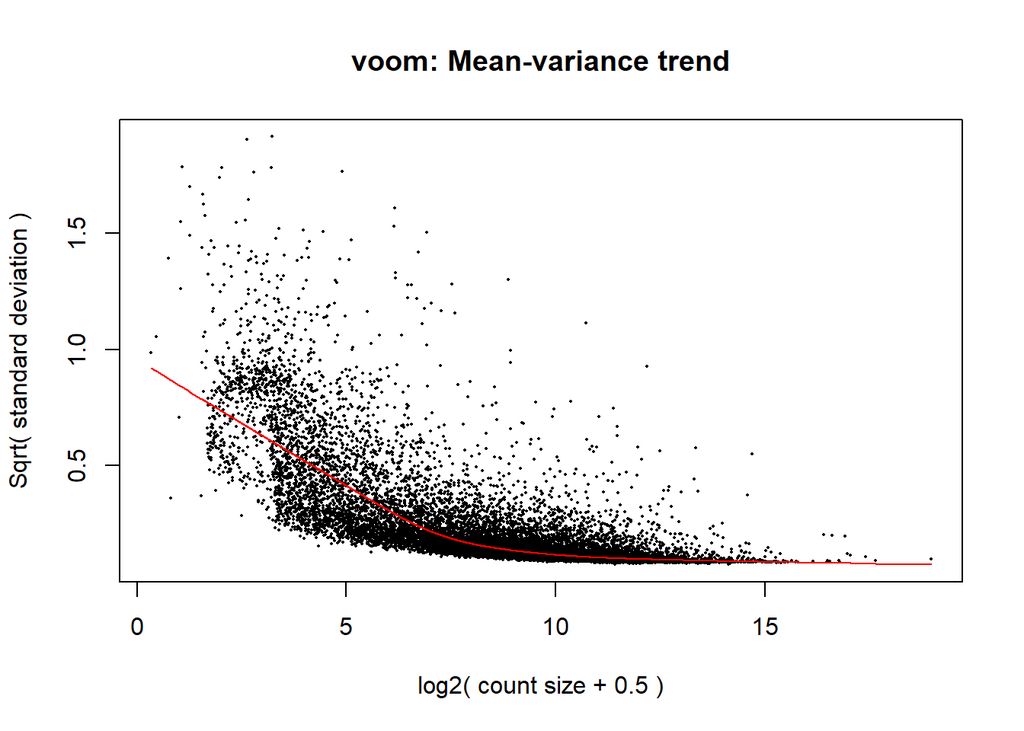

```r
# prepare the design
variables <- matrix(unlist(strsplit(colnames(normalizedCPMcountsCortex), "_")), ncol=2, byrow=TRUE)
colnames(variables) <- c("samplename","mappingref")
strains <- gsub("_Kallisto","",variables[,"samplename"])
strains <- factor(gsub("_STAR","",variables[,"samplename"]))
design <- model.matrix(~strains+factor(variables[,"mappingref"]))

# by default the normalization method is quantile (voom calls normalizeBetweenArrays)
# plot the mean-variance trend
##res <- voom(countsCortex, design, plot=TRUE, lib.size=colSums(countsCortex)*dC$samples$norm.factors)
resC <- voom(dC, design, plot=TRUE)
```

```r
resCortexNorm <- resC$E

# fitting
# fit the coefficient of the linear model
fitC <- lmFit(resC, design)
# calculates the t-statistics
fitC2 <- eBayes(fitC)

# write all results
resultTable <- topTable(fitC2, coef=ncol(fitC$coefficients), adjust="fdr", sort.by="B", number=1000000)
# sort by adjusted p-value
resultTable <- resultTable[order(resultTable$adj.P.Val),]

# store information about DE analysis
write.table(resultTable, file="F:/BXD/data/transcriptome/5_DifferentialMapping/DifferentialMappingSTARKallisto_Limma_Cortex.txt", row.names=TRUE, sep="\t", quote=FALSE)
```

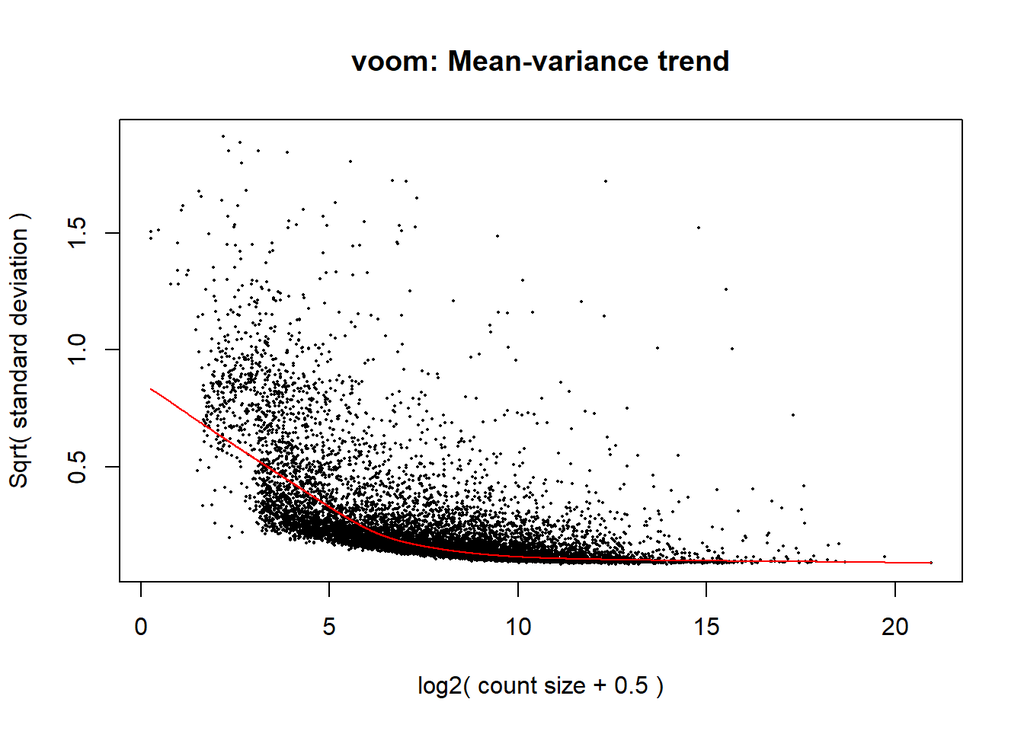

```r
# prepare the design
variables <- matrix(unlist(strsplit(colnames(normalizedCPMcountsLiver), "_")), ncol=2, byrow=TRUE)
colnames(variables) <- c("samplename","mappingref")
strains <- factor(gsub("[Cnsd]","",variables[,"samplename"]))
design <- model.matrix(~strains+factor(variables[,"mappingref"]))

# by default the normalization method is quantile (voom calls normalizeBetweenArrays)
# plot the mean-variance trend
##res <- voom(countsLiver, design, plot=TRUE, lib.size=colSums(countsLiver)*dL$samples$norm.factors)
resL <- voom(dL, design, plot=TRUE)
```

```r
resLiverNorm <- resL$E

# fitting
# fit the coefficient of the linear model
fitL <- lmFit(resL, design)
# calculates the t-statistics
fitL2 <- eBayes(fitL)

# write all results
resultTable <- topTable(fitL2, coef=ncol(fitL$coefficients), adjust="fdr", sort.by="B", number=1000000)
# sort by adjusted p-value
resultTable <- resultTable[order(resultTable$adj.P.Val),]

# store information about DE analysis
write.table(resultTable, file="F:/BXD/data/transcriptome/5_DifferentialMapping/DifferentialMappingSTARKallisto_Limma_Liver.txt", row.names=TRUE, sep="\t", quote=FALSE)
```

# Plotting results

Volcano plots

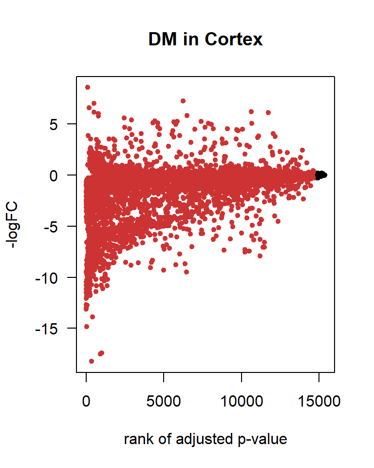

```r
# load table with results of differential expression
DMdata_Cortex <- read.table('F:/BXD/data/transcriptome/5_DifferentialMapping/DifferentialMappingSTARKallisto_Limma_Cortex.txt', sep="\t")
DMdata_Liver <- read.table('F:/BXD/data/transcriptome/5_DifferentialMapping/DifferentialMappingSTARKallisto_Limma_Liver.txt', sep="\t")

# volcano plot all transcripts in black and significant in red
# set the colors
palette(c("black", "brown3"))

# plot for Cortex
plot(1:nrow(DMdata_Cortex), DMdata_Cortex$logFC, las=1, pch=20, col=as.factor(DMdata_Cortex$adj.P.Val<=0.05),
       main="DM in Cortex", xlab="rank of adjusted p-value", ylab="-logFC")
```

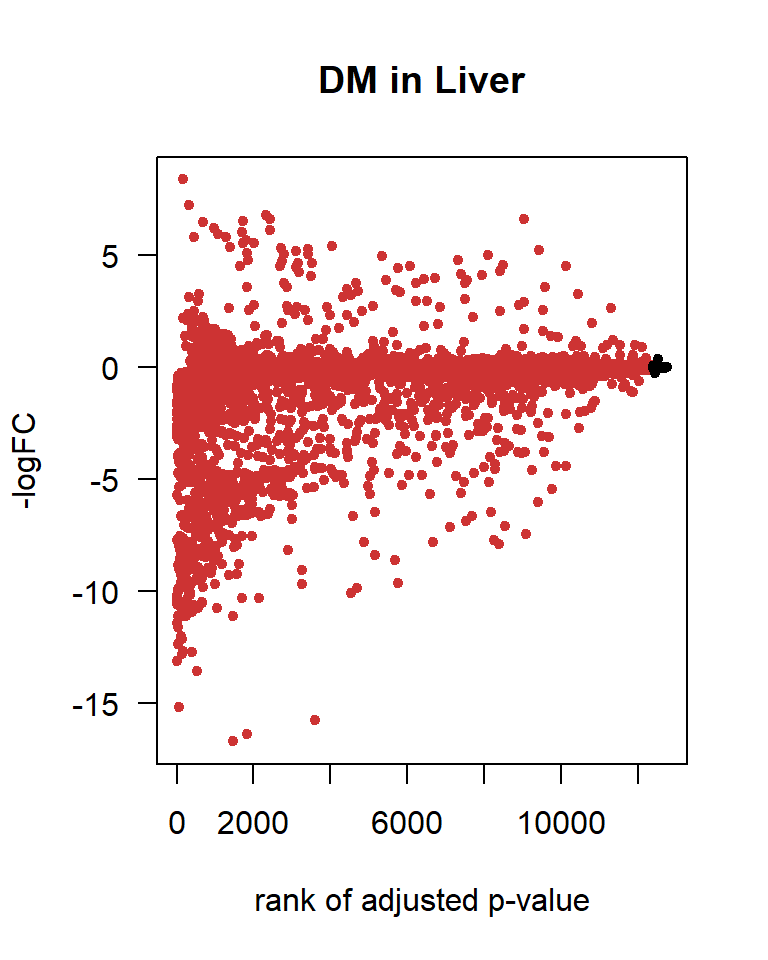

```r
# plot for Liver
plot(1:nrow(DMdata_Liver), DMdata_Liver$logFC, las=1, pch=20, col=as.factor(DMdata_Liver$adj.P.Val<=0.05),
       main="DM in Liver", xlab="rank of adjusted p-value", ylab="-logFC")
```

97% of genes are significantly (below or equal to 0.05) differentially mapped in cortex, and 97% in liver.

```r
# get top 5 up- and top 5 down-measured genes
DMdata_Cortex <- DMdata_Cortex[order(DMdata_Cortex$logFC),]
head(DMdata_Cortex,5)
```

|  | logFC | AveExpr | t | P.Value | adj.P.Val | B |
| --- | --- | --- | --- | --- | --- | --- |
| mt-Co3 | -18.22868 | 3.641563 | -164.03935 | 3.136039e-110 | 1.310575e-108 | 236.4578 |
| mt-Atp6 | -17.52347 | 4.073833 | -104.51980 | 2.797411e-93 | 4.591396e-92 | 201.6730 |
| mt-Co2 | -17.40948 | 4.073511 | -98.82287 | 3.531254e-91 | 5.361022e-90 | 197.1433 |
| mt-Nd4l | -14.85687 | 1.675124 | -355.58127 | 1.989373e-139 | 7.115014e-137 | 283.2019 |
| Gm20594 | -13.89868 | 1.603019 | -154.94202 | 4.424732e-108 | 1.604905e-106 | 232.1465 |

```r
print(head(DMdata_Cortex[,c("logFC","adj.P.Val")],5))
```

```
##             logFC     adj.P.Val
## mt-Co3  -18.22868 1.310575e-108
## mt-Atp6 -17.52347  4.591396e-92
## mt-Co2  -17.40948  5.361022e-90
## mt-Nd4l -14.85687 7.115014e-137
## Gm20594 -13.89868 1.604905e-106
```

```r
tail(DMdata_Cortex,5)
```

|  | logFC | AveExpr | t | P.Value | adj.P.Val | B |
| --- | --- | --- | --- | --- | --- | --- |
| Smt3h2-ps | 6.203553 | -2.480529 | 19.15874 | 5.663079e-33 | 8.188464e-33 | 64.33122 |
| Btbd8 | 6.592349 | 3.799109 | 207.38391 | 4.526595e-119 | 3.222893e-117 | 262.68768 |
| B430305J03Rik | 6.993440 | -2.302805 | 138.87152 | 5.871029e-104 | 1.703595e-102 | 223.74535 |
| Mia2 | 7.256568 | 1.334742 | 33.99013 | 5.016944e-52 | 1.231337e-51 | 108.08850 |
| Gm14303 | 8.562993 | -1.579775 | 265.33591 | 2.265662e-128 | 3.287134e-126 | 268.04317 |

```r
print(tail(DMdata_Cortex[,c("logFC","adj.P.Val")],5))
```

```
##                  logFC     adj.P.Val
## Smt3h2-ps     6.203553  8.188464e-33
## Btbd8         6.592349 3.222893e-117
## B430305J03Rik 6.993440 1.703595e-102
## Mia2          7.256568  1.231337e-51
## Gm14303       8.562993 3.287134e-126
```

```r
DMdata_Liver <- DMdata_Liver[order(DMdata_Liver$logFC),]
head(DMdata_Liver,5)
```

|  | logFC | AveExpr | t | P.Value | adj.P.Val | B |
| --- | --- | --- | --- | --- | --- | --- |
| mt-Co2 | -16.68481 | 4.234043 | -58.34581 | 1.841652e-71 | 1.596473e-70 | 153.0232 |
| mt-Atp6 | -16.35212 | 4.668776 | -51.78823 | 4.349687e-67 | 3.035035e-66 | 143.0411 |
| mt-Co3 | -15.72365 | 4.205619 | -36.52362 | 1.699087e-54 | 6.024893e-54 | 114.0254 |
| mt-Nd4l | -15.18039 | 1.661280 | -217.89880 | 9.826857e-121 | 1.991732e-118 | 254.2599 |
| Mup16 | -13.57069 | 3.689950 | -102.34120 | 2.411321e-92 | 5.820445e-91 | 200.9362 |

```r
print(head(DMdata_Liver[,c("logFC","adj.P.Val")],5))
```

```
##             logFC     adj.P.Val
## mt-Co2  -16.68481  1.596473e-70
## mt-Atp6 -16.35212  3.035035e-66
## mt-Co3  -15.72365  6.024893e-54
## mt-Nd4l -15.18039 1.991732e-118
## Mup16   -13.57069  5.820445e-91
```

```r
tail(DMdata_Liver,5)
```

|  | logFC | AveExpr | t | P.Value | adj.P.Val | B |
| --- | --- | --- | --- | --- | --- | --- |
| Gm14513 | 6.607997 | -3.5072609 | 16.26446 | 4.262556e-28 | 6.018863e-28 | 53.03176 |
| Scp2-ps2 | 6.610960 | 0.7080593 | 44.52052 | 1.372564e-61 | 7.239268e-61 | 130.22135 |
| Gm11273 | 6.782478 | -1.7157358 | 45.35288 | 2.932458e-62 | 1.608443e-61 | 131.92416 |
| Gm11966 | 7.252092 | -2.4607789 | 128.38123 | 7.695094e-101 | 3.042063e-99 | 216.82984 |
| Gm14303 | 8.372800 | -1.8999846 | 168.67159 | 4.268391e-111 | 3.303217e-109 | 237.05610 |

```r
print(tail(DMdata_Liver[,c("logFC","adj.P.Val")],5))
```

```
##             logFC     adj.P.Val
## Gm14513  6.607997  6.018863e-28
## Scp2-ps2 6.610960  7.239268e-61
## Gm11273  6.782478  1.608443e-61
## Gm11966  7.252092  3.042063e-99
## Gm14303  8.372800 3.303217e-109
```

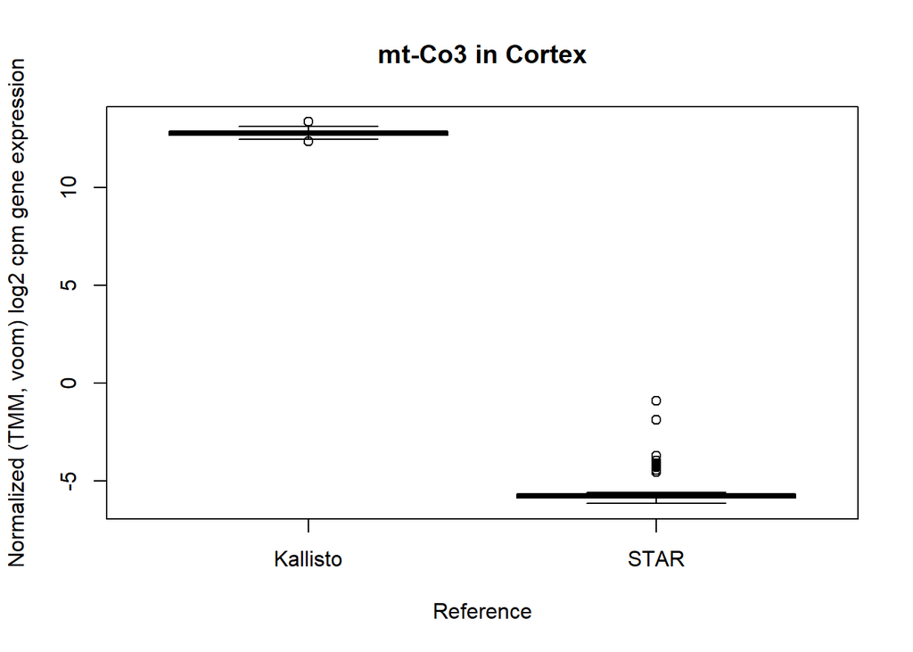

```
## $stats
##          [,1]      [,2]
## [1,] 12.47101 -6.161112
## [2,] 12.70288 -5.883968
## [3,] 12.79156 -5.773993
## [4,] 12.88816 -5.674244
## [5,] 13.13037 -5.597413
##
## $n
## [1] 86 86
##
## $conf
##          [,1]      [,2]
## [1,] 12.75999 -5.809725
## [2,] 12.82312 -5.738261
##
## $out
##  [1] 12.3729829 13.3682067 -4.2510141 -4.2584847 -4.4352193 -4.1259361
##  [7] -4.0942111 -3.9706069 -0.8963779 -3.7076012 -4.1692911 -4.5421816
## [13] -4.3148870 -1.8780458
##
## $group
##  [1] 1 1 2 2 2 2 2 2 2 2 2 2 2 2
##
## $names
## [1] "Kallisto" "STAR"
```

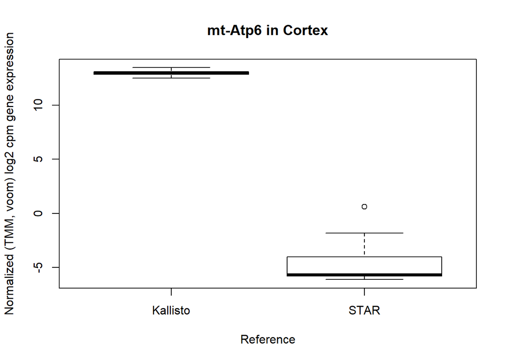

```
## $stats
##          [,1]      [,2]
## [1,] 12.50147 -6.124345
## [2,] 12.86338 -5.813970
## [3,] 12.97431 -5.676951
## [4,] 13.11834 -4.037842
## [5,] 13.47948 -1.837783
##
## $n
## [1] 86 86
##
## $conf
##          [,1]      [,2]
## [1,] 12.93087 -5.979560
## [2,] 13.01775 -5.374341
##
## $out
## [1] 0.621792
##
## $group
## [1] 2
##
## $names
## [1] "Kallisto" "STAR"
```

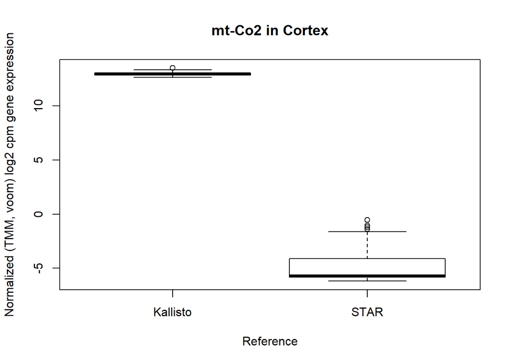

```
## $stats
##          [,1]      [,2]
## [1,] 12.61604 -6.181780
## [2,] 12.83483 -5.815240
## [3,] 12.94508 -5.674486
## [4,] 13.04772 -4.099100
## [5,] 13.33976 -1.636041
##
## $n
## [1] 86 86
##
## $conf
##          [,1]      [,2]
## [1,] 12.90881 -5.966875
## [2,] 12.98136 -5.382097
##
## $out
## [1] 13.4849007 -0.5490702 -1.2096219 -1.3856731 -1.0743669
##
## $group
## [1] 1 2 2 2 2
##
## $names
## [1] "Kallisto" "STAR"
```

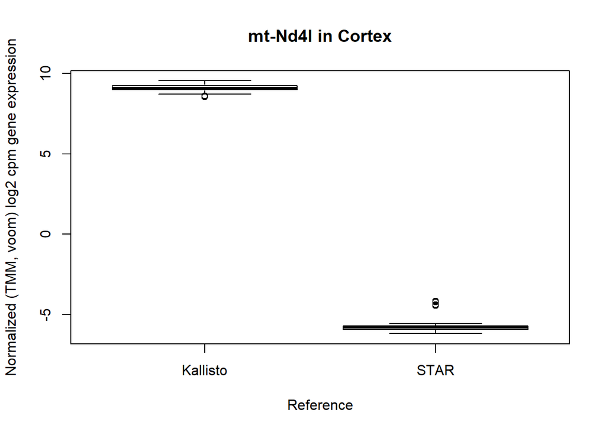

```
## $stats
##          [,1]      [,2]
## [1,] 8.720271 -6.181780
## [2,] 8.994217 -5.912019
## [3,] 9.100239 -5.797145
## [4,] 9.240473 -5.710899
## [5,] 9.550940 -5.555569
##
## $n
## [1] 86 86
##
## $conf
##          [,1]      [,2]
## [1,] 9.058283 -5.831411
## [2,] 9.142195 -5.762879
##
## $out
## [1]  8.623871  8.563535 -4.442841 -4.379547 -4.165986 -4.220591
##
## $group
## [1] 1 1 2 2 2 2
##
## $names
## [1] "Kallisto" "STAR"
```

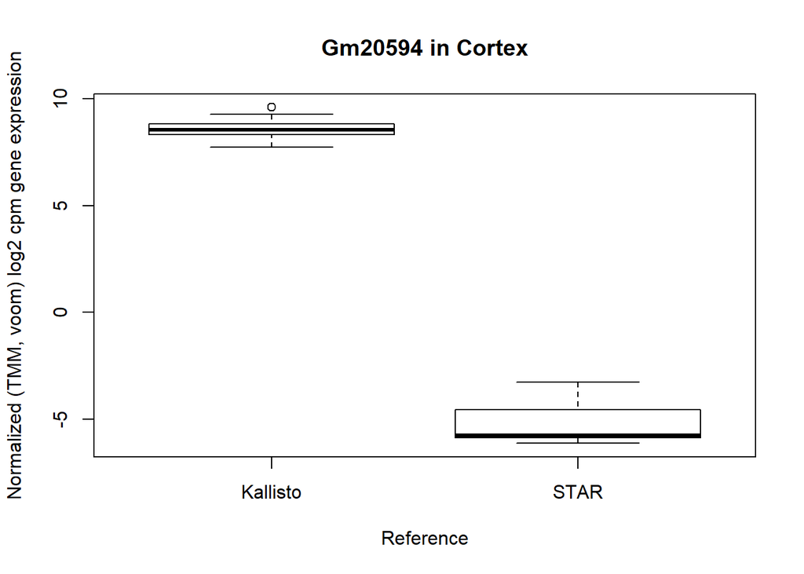

```
## $stats
##          [,1]      [,2]
## [1,] 7.738768 -6.124345
## [2,] 8.305045 -5.858424
## [3,] 8.540361 -5.747790
## [4,] 8.814607 -4.552456
## [5,] 9.268418 -3.275485
##
## $n
## [1] 86 86
##
## $conf
##          [,1]      [,2]
## [1,] 8.453544 -5.970296
## [2,] 8.627178 -5.525285
##
## $out
## [1] 9.590906
##
## $group
## [1] 1
##
## $names
## [1] "Kallisto" "STAR"
```

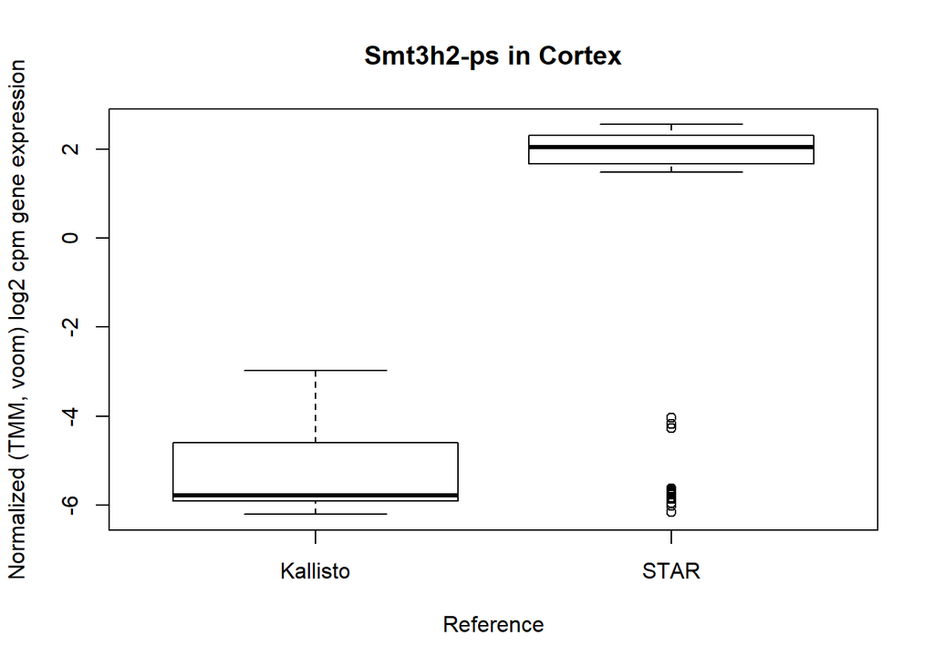

```
## $stats
##           [,1]     [,2]
## [1,] -6.210484 1.489321
## [2,] -5.903697 1.669845
## [3,] -5.793628 2.044794
## [4,] -4.593668 2.307874
## [5,] -2.977746 2.556390
##
## $n
## [1] 86 86
##
## $conf
##           [,1]     [,2]
## [1,] -6.016825 1.936090
## [2,] -5.570430 2.153499
##
## $out
##  [1] -5.835977 -5.683252 -5.955249 -5.698579 -5.862601 -5.626705 -5.768426
##  [8] -6.020182 -5.710899 -5.833467 -4.273462 -4.182548 -5.670931 -4.042140
## [15] -5.624837 -5.674728 -5.737311 -5.661066 -6.161112
##
## $group
##  [1] 2 2 2 2 2 2 2 2 2 2 2 2 2 2 2 2 2 2 2
##
## $names
## [1] "Kallisto" "STAR"
```

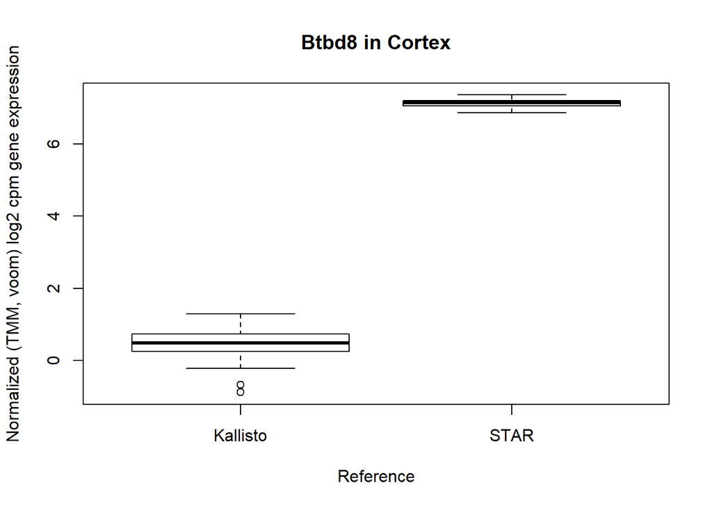

```
## $stats
##            [,1]     [,2]
## [1,] -0.2197908 6.855918
## [2,]  0.2572049 7.049198
## [3,]  0.4836921 7.138824
## [4,]  0.7418779 7.206010
## [5,]  1.2917791 7.354838
##
## $n
## [1] 86 86
##
## $conf
##           [,1]     [,2]
## [1,] 0.4011156 7.112107
## [2,] 0.5662687 7.165542
##
## $out
## [1] -0.6673838 -0.8777635
##
## $group
## [1] 1 1
##
## $names
## [1] "Kallisto" "STAR"
```

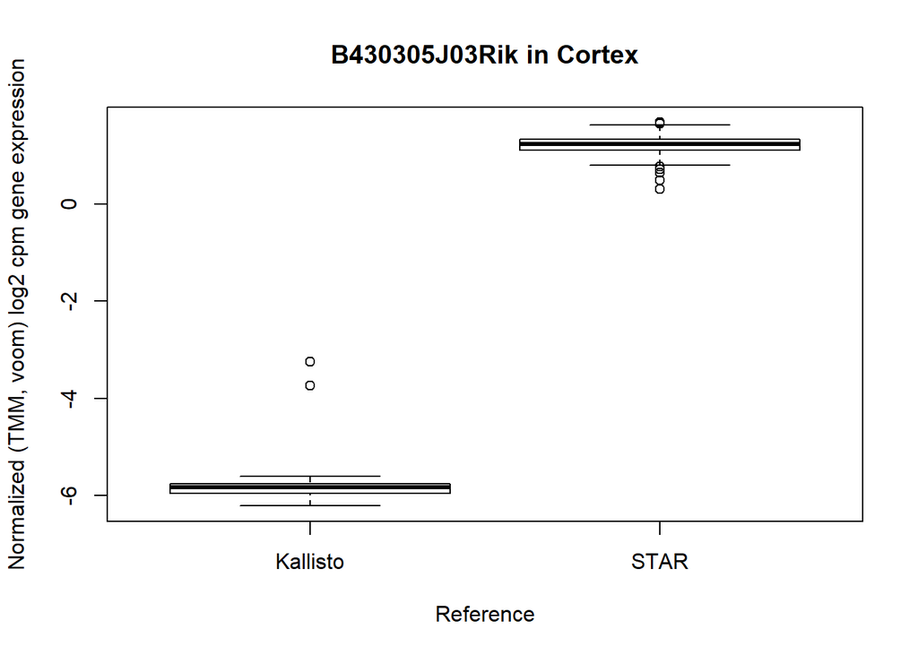

```
## $stats
##           [,1]     [,2]
## [1,] -6.210484 0.793380
## [2,] -5.952786 1.106783
## [3,] -5.831062 1.232538
## [4,] -5.764765 1.322703
## [5,] -5.598494 1.616194
##
## $n
## [1] 86 86
##
## $conf
##           [,1]     [,2]
## [1,] -5.863096 1.195751
## [2,] -5.799027 1.269326
##
## $out
## [1] -3.2407223 -3.7358737  0.6384884  1.6493888  0.7146368  0.7637699
## [7]  0.4857198  1.6729573  0.3030357
##
## $group
## [1] 1 1 2 2 2 2 2 2 2
##
## $names
## [1] "Kallisto" "STAR"
```

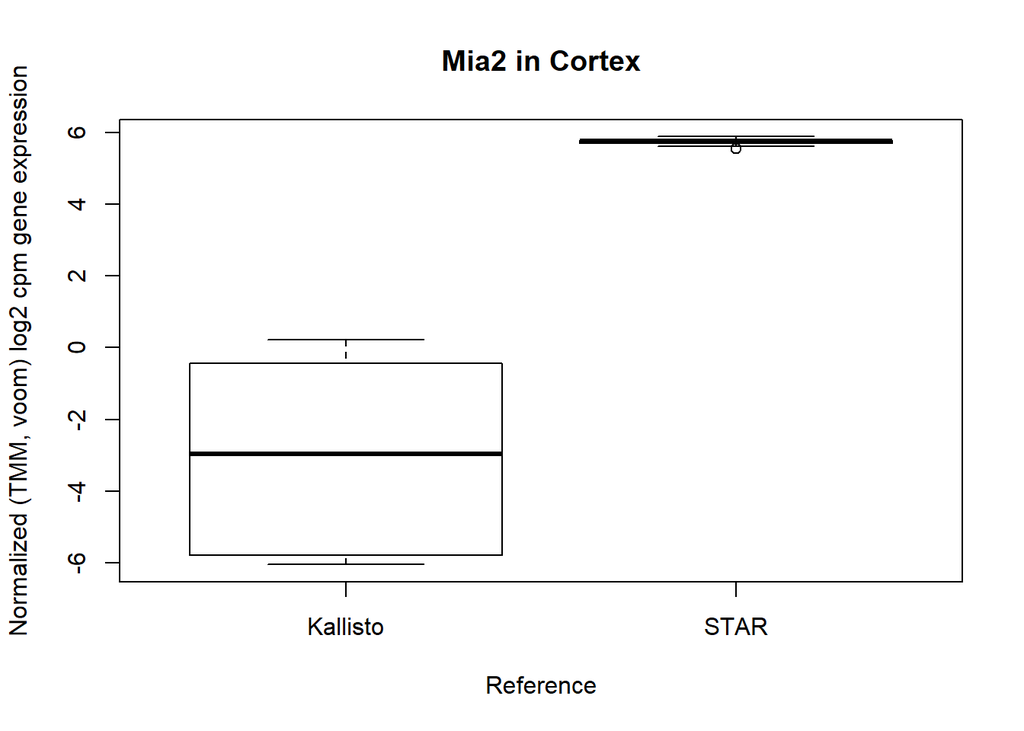

```
## $stats
##            [,1]     [,2]
## [1,] -6.0480773 5.609907
## [2,] -5.7851009 5.707146
## [3,] -2.9694249 5.760429
## [4,] -0.4386019 5.784272
## [5,]  0.2233886 5.882501
##
## $n
## [1] 86 86
##
## $conf
##           [,1]     [,2]
## [1,] -3.880339 5.747289
## [2,] -2.058511 5.773570
##
## $out
## [1] 5.558776
##
## $group
## [1] 2
##
## $names
## [1] "Kallisto" "STAR"
```

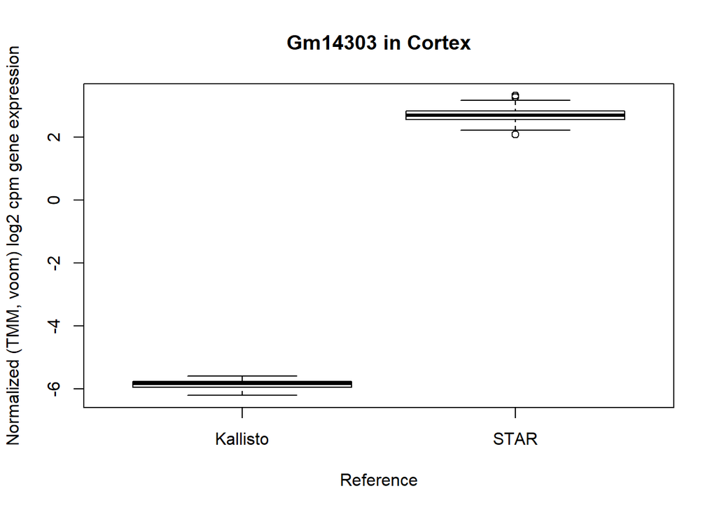

```
## $stats
##           [,1]     [,2]
## [1,] -6.210484 2.233620
## [2,] -5.956663 2.558650
## [3,] -5.833789 2.700655
## [4,] -5.768906 2.841904
## [5,] -5.598494 3.167896
##
## $n
## [1] 86 86
##
## $conf
##           [,1]     [,2]
## [1,] -5.865778 2.652395
## [2,] -5.801800 2.748914
##
## $out
## [1] 3.321370 3.278086 2.090458
##
## $group
## [1] 2 2 2
##
## $names
## [1] "Kallisto" "STAR"
```

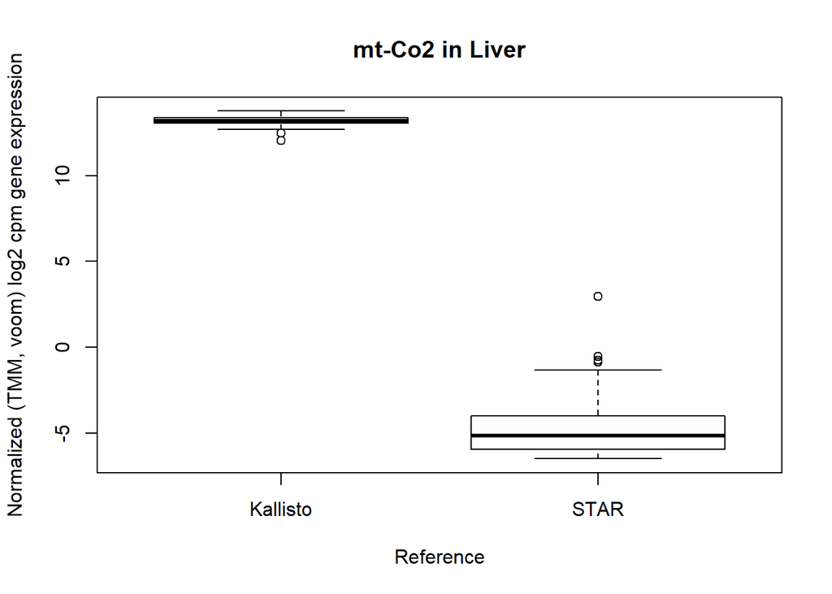

```
## $stats
##          [,1]      [,2]
## [1,] 12.67611 -6.489842
## [2,] 13.04041 -5.957734
## [3,] 13.17560 -5.146102
## [4,] 13.38326 -3.988554
## [5,] 13.75511 -1.343741
##
## $n
## [1] 86 86
##
## $conf
##          [,1]      [,2]
## [1,] 13.11718 -5.481602
## [2,] 13.23401 -4.810601
##
## $out
## [1] 12.4862019 12.0315363  2.9648238 -0.5324867 -0.7534272 -0.8781858
##
## $group
## [1] 1 1 2 2 2 2
##
## $names
## [1] "Kallisto" "STAR"
```

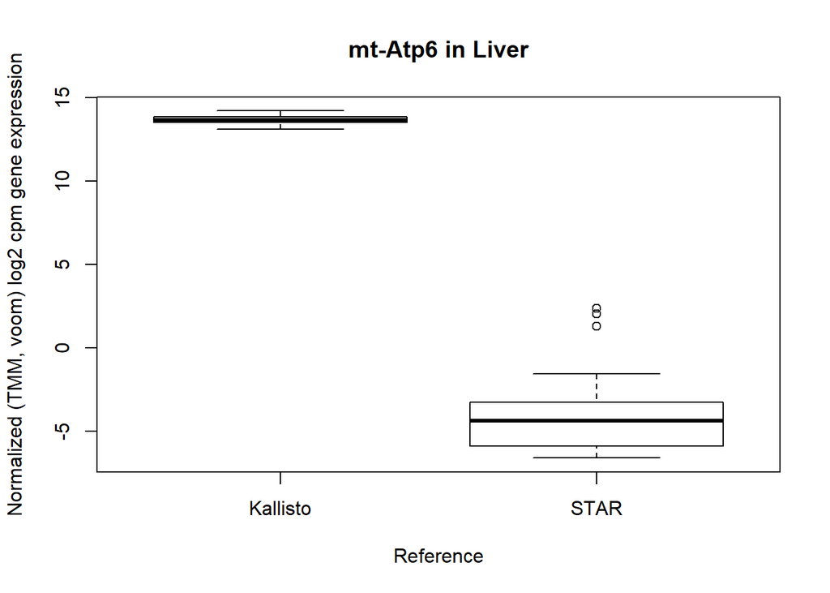

```
## $stats
##          [,1]      [,2]
## [1,] 13.10198 -6.613250
## [2,] 13.50279 -5.901158
## [3,] 13.64899 -4.366611
## [4,] 13.83836 -3.273044
## [5,] 14.18973 -1.560604
##
## $n
## [1] 86 86
##
## $conf
##          [,1]      [,2]
## [1,] 13.59182 -4.814378
## [2,] 13.70617 -3.918844
##
## $out
## [1] 2.021762 2.344212 1.283765
##
## $group
## [1] 2 2 2
##
## $names
## [1] "Kallisto" "STAR"
```

[8 more figures not shown]

```
## $stats
##           [,1]     [,2]
## [1,] -6.669260 1.365440
## [2,] -6.221601 2.012846
## [3,] -6.084056 2.283755
## [4,] -5.920116 2.543292
## [5,] -5.562752 3.232886
##
## $n
## [1] 86 86
##
## $conf
##           [,1]    [,2]
## [1,] -6.135422 2.19338
## [2,] -6.032691 2.37413
##
## $out
## [1] -6.780154 -6.819775 -5.307309
##
## $group
## [1] 1 1 1
##
## $names
## [1] "Kallisto" "STAR"
```

```r
for (mytissue in c("Cortex","Liver")){
  completelist <- rownames(get(paste("DMdata_", mytissue, sep="")))
  for (mygene in c(head(completelist, 5), tail(completelist, 5))){
    print(boxplot(as.numeric(get(paste("res", mytissue, "Norm", sep=""))[mygene,]) ~ factor(variables[, "mappingref"]), main=paste(mygene, "in", mytissue), xlab="Reference", ylab="Normalized (TMM, voom) log2 cpm gene expression"))
  }
}
```

```r
# how many have a log fold change (absolute value) above 2?
length(which(abs(DMdata_Cortex$logFC)>2))
```

```
## [1] 1192
```

```r
length(which(abs(DMdata_Liver$logFC)>2))
```

```
## [1] 841
```

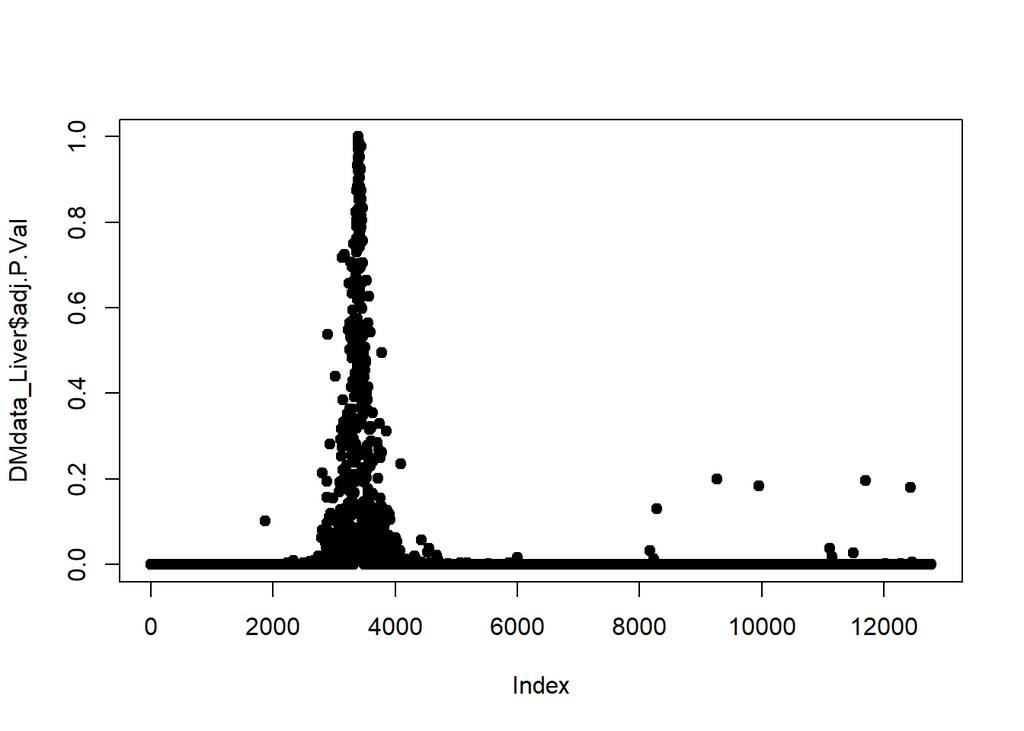

```r
# testing
plot(DMdata_Liver$adj.P.Val, pch=19)
```

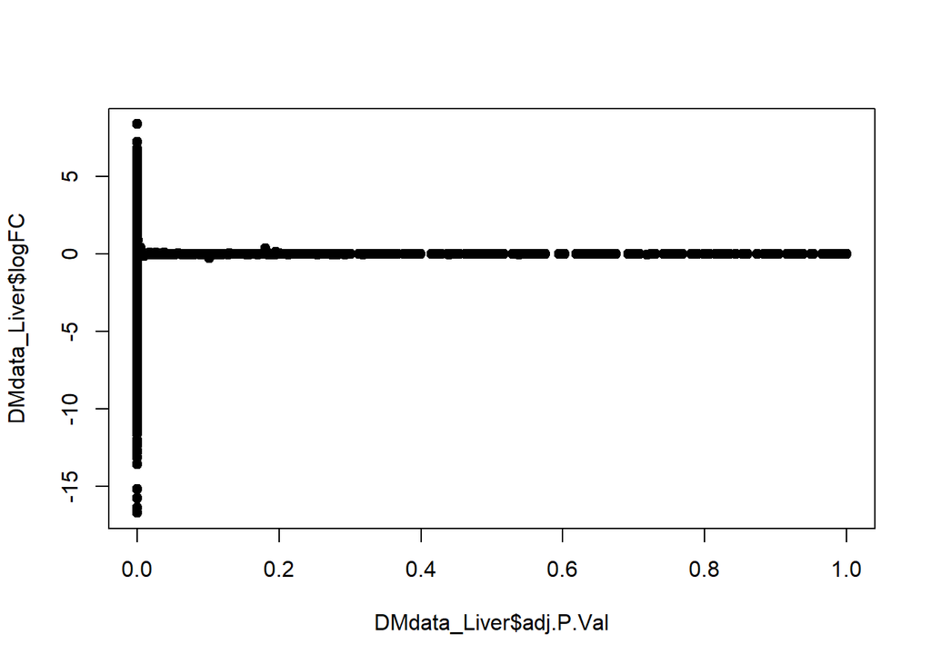

```r
plot(DMdata_Liver$adj.P.Val,DMdata_Liver$logFC, pch=19)
```

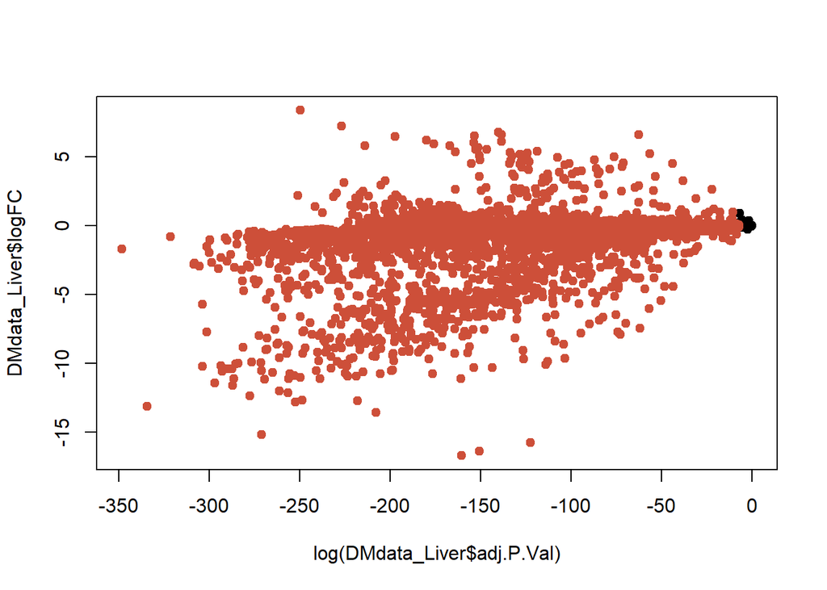

```r
plot(log(DMdata_Liver$adj.P.Val),DMdata_Liver$logFC, pch=19)
points(log(DMdata_Liver$adj.P.Val[abs(DMdata_Liver$adj.P.Val)<0.001]),DMdata_Liver$logFC[abs(DMdata_Liver$adj.P.Val)<0.001], pch=19, col="tomato3")
```